# Causal Analysis HW2

Haochun Niu , Runan Cao, Shuyun Liu, Chuyun Hsiao

## (a) What is Wrong with Bob’s RoI Calculation?

**Based on Bob’s ROI calculation, he says “the average probability of making a purchase from a website is 12%”. Bob considers CTR (click-through rate) as a conversion on the landing page. The CTR in this case is Ad Clicks / (Sponsored Clicks + Organic Clicks). However, this formula ignores people who never click on any sponsored or organic searches.**

**Further, if we dig into how Bob finds customers who click on his ads. For those customers who use “Bazaar” to search and then click on an ad, they are already using Bazaar to search. Even if it wasn’t added, they should have clicked on the link in the organic listing because they’ve specifically entered “Bazaar” in the search bar. Bazaar is able to acquire this group of customers for free.**

## (b)Define the Treatment and Control.

**In this scenario, the unit of observation is the weekly traffic from each platform. We set the searching platform Google as a treatment group, and all the other platforms (Bing, yahoo, ask) as control groups.**

## (c) Consider a First Difference Estimate.

**We built a regression model (avg_org = beta_0 +beta_1 After) on the treated group (Google). After is a dummy variable representing the intervention.The coefficient beta_1 is equal to 4277.3, which indicates an average increase of 4277.3 in average organic clicks after stopping sponsored search ads. Before the intervention, the mean of average organic click is 2266.7. Therefore, the percentage change is equal to 188.7%.**

**However, it is not a good idea to solely rely on this number, as the target variable (average organic clicks) will naturally change over time. Indeed, the beta_1 estimate have a high probability of amplifying the causal effect of the intervention. Comparing just the before and after of treated units is unreliable. Instead, we should have a control group to represent the counterfactual to capture what would have happened without the intervention.**

```r
library(tidyverse)
library(caret)
```

```r
# Prepare Data
df<-read_csv("did_sponsored_ads.csv")
df<-df%>%select(platform,week,avg_org)
df$treatment<-ifelse(df$platform=='goog','treatment','control')
df$treatment<-as.factor(df$treatment)
df<-df%>%select(-platform)
df$After<-ifelse(df$week>9,'After','Before')
df$week<-as.factor(df$week)
df$After<-factor(df$After,level=unique(c('Before','After')))
```

```r
model1<-lm(avg_org~After,data=filter(df,treatment=='treatment'))
summary(model1)
```

```
##
## Call:
## lm(formula = avg_org ~ After, data = filter(df, treatment ==
##     "treatment"))
##
## Residuals:
##      Min       1Q   Median       3Q      Max
## -1753.67  -631.92    26.67   505.83  2067.33
##
## Coefficients:
##             Estimate Std. Error t value Pr(>|t|)
## (Intercept)   2266.7      402.7   5.629 0.000219 ***
## AfterAfter    4277.3      805.4   5.311 0.000342 ***
## ---
## Signif. codes:  0 '***' 0.001 '**' 0.01 '*' 0.05 '.' 0.1 ' ' 1
##
## Residual standard error: 1208 on 10 degrees of freedom
## Multiple R-squared:  0.7383, Adjusted R-squared:  0.7121
## F-statistic: 28.21 on 1 and 10 DF,  p-value: 0.0003422
```

```r
df %>% group_by(treatment,After) %>% summarise(mean_avg_org = mean(avg_org))
```

```
## # A tibble: 4 × 3
## # Groups:   treatment [2]
##   treatment After  mean_avg_org
##   <fct>     <fct>         <dbl>
## 1 control   Before        1490.
## 2 control   After         3474.
## 3 treatment Before        2267.
## 4 treatment After         6544
```

```r
per_change = (4277.3)/2266.7 *100
per_change
```

```
## [1] 188.7016
```

## (d) Calculate the Difference-in-Differences.

**We built a regression model (avg_org = beta_0 + beta_1 After + beta_2 treatment + beta_3 Aftertreatment ) ,where After represents the intervention and treatment represents the treatment group. beta_3 indicates the changes in average organic click over time between the treatment group and the control group. Therefore the causal effect of stopping sponsored serving is 2293.2. If we stopped sponsored search ads, the average organic clicks would have increased by 2293.2 on average.**

**This estimate is now smaller than the previous one, indicating that the previous estimate was not accurate. If we only consider treated units, we would incorrectly amplify causal effects.**

```r
# Check Parallel Trends Assumptions Before DiD Analysis
model2<-lm(avg_org~week*treatment,data=df)
summary(lm(model2))
```

```
##
## Call:
## lm(formula = model2)
##
## Residuals:
##      Min       1Q   Median       3Q      Max
## -1819.33   -43.67    12.67   299.42  1532.67
##
## Coefficients:
##                           Estimate Std. Error t value Pr(>|t|)
## (Intercept)                  302.7      556.5   0.544 0.591544
## week2                        237.0      787.0   0.301 0.765901
## week3                        569.0      787.0   0.723 0.476673
## week4                        805.0      787.0   1.023 0.316574
## week5                       1078.7      787.0   1.371 0.183186
## week6                       1558.0      787.0   1.980 0.059323 .
## week7                       1816.3      787.0   2.308 0.029937 *
## week8                       2193.3      787.0   2.787 0.010235 *
## week9                       2425.7      787.0   3.082 0.005101 **
## week10                      2896.0      787.0   3.680 0.001178 **
## week11                      3200.7      787.0   4.067 0.000445 ***
## week12                      3416.7      787.0   4.341 0.000222 ***
## treatmenttreatment           210.3     1113.0   0.189 0.851698
## week2:treatmenttreatment       6.0     1574.0   0.004 0.996990
## week3:treatmenttreatment     115.0     1574.0   0.073 0.942363
## week4:treatmenttreatment     538.0     1574.0   0.342 0.735476
## week5:treatmenttreatment     587.3     1574.0   0.373 0.712318
## week6:treatmenttreatment     487.0     1574.0   0.309 0.759688
## week7:treatmenttreatment     925.7     1574.0   0.588 0.561964
## week8:treatmenttreatment    1045.7     1574.0   0.664 0.512812
## week9:treatmenttreatment    1395.3     1574.0   0.886 0.384156
## week10:treatmenttreatment   2649.0     1574.0   1.683 0.105350
## week11:treatmenttreatment   2971.3     1574.0   1.888 0.071211 .
## week12:treatmenttreatment   2959.3     1574.0   1.880 0.072284 .
## ---
## Signif. codes:  0 '***' 0.001 '**' 0.01 '*' 0.05 '.' 0.1 ' ' 1
##
## Residual standard error: 963.9 on 24 degrees of freedom
## Multiple R-squared:  0.8399, Adjusted R-squared:  0.6864
## F-statistic: 5.473 on 23 and 24 DF,  p-value: 5.034e-05
```

```r
model3<-lm(avg_org~ After + treatment + After*treatment,data=df)
summary(model3)
```

```
##
## Call:
## lm(formula = avg_org ~ After + treatment + After * treatment,
##     data = df)
##
## Residuals:
##      Min       1Q   Median       3Q      Max
## -1928.78  -847.92   -52.67   825.00  2067.33
##
## Coefficients:
##                               Estimate Std. Error t value Pr(>|t|)
## (Intercept)                     1489.7      215.4   6.917 1.51e-08 ***
## AfterAfter                      1984.1      430.7   4.607 3.49e-05 ***
## treatmenttreatment               777.0      430.7   1.804   0.0781 .
## AfterAfter:treatmenttreatment   2293.2      861.4   2.662   0.0108 *
## ---
## Signif. codes:  0 '***' 0.001 '**' 0.01 '*' 0.05 '.' 0.1 ' ' 1
##
## Residual standard error: 1119 on 44 degrees of freedom
## Multiple R-squared:  0.6043, Adjusted R-squared:  0.5773
## F-statistic:  22.4 on 3 and 44 DF,  p-value: 5.881e-09
```

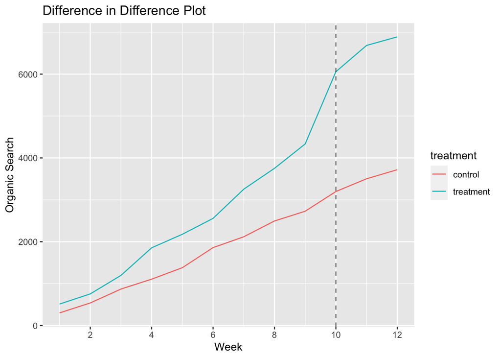

```r
plot_df<-df%>%group_by(week,treatment)%>%summarise('Organic Search'=mean(avg_org))
ggplot(plot_df,aes(x=as.numeric(week),y=`Organic Search`,group=treatment,color=treatment))+
  geom_line()+
  geom_vline(xintercept = 10,linetype=2,alpha=0.6)+
  scale_x_continuous(breaks = c(0,2,4,6,8,10,12))+
  labs(x='Week',title = 'Difference in Difference Plot')
```

## (e) Given Your Treatment Effect Estimate, Fix Bob’s RoI Calculation

**If google did not stop the sponsored ads, the average sponsored clicks would be 9855.9 However, this number includes parts of organic clicks (2293.2). Therefore, the ROI should be adjusted by (9855.9 - 2293.2)/9855.9. The ajusted ROI is equal to 245.54%**

```r
# prepare the data
df1<-read_csv("did_sponsored_ads.csv")
df1<-df1%>%select(platform,week,avg_spons)
df1$treatment<-ifelse(df1$platform=='goog','treatment','control')
df1$treatment<-as.factor(df1$treatment)
df1<-df1%>%select(-platform)
df1$After<-ifelse(df1$week>9,'After','Before')
df1$week<-as.factor(df1$week)
df1$After<-factor(df1$After,level=unique(c('Before','After')))
```

```r
# #Whether the average sponsor differs between control and treatment group before week 10?
model4<-lm(avg_spons~treatment,data=filter(df1,After=='Before'))
summary(model4)
```

```
##
## Call:
## lm(formula = avg_spons ~ treatment, data = filter(df1, After ==
##     "Before"))
##
## Residuals:
##     Min      1Q  Median      3Q     Max
## -5250.2 -2331.0  -701.3  2663.2  6627.7
##
## Coefficients:
##                    Estimate Std. Error t value Pr(>|t|)
## (Intercept)          3775.3      612.7   6.161 5.32e-07 ***
## treatmenttreatment   2347.9     1225.5   1.916   0.0638 .
## ---
## Signif. codes:  0 '***' 0.001 '**' 0.01 '*' 0.05 '.' 0.1 ' ' 1
##
## Residual standard error: 3184 on 34 degrees of freedom
## Multiple R-squared:  0.09744,    Adjusted R-squared:  0.0709
## F-statistic: 3.671 on 1 and 34 DF,  p-value: 0.06382
```

```r
#Given that the p-value for the treatment feature is large, we conclude that average sponsors for treatment and control group are not different before week 10.
```

```r
#Hence, we use control group's average sponsor to estimate treatment group's average sponsor after week 9
tem<-df1%>%filter(After=='After' & treatment=='control')
mean(tem$avg_spons)
```

```
## [1] 9855.889
```

```r
asj_ROI= (2.52-0.6) * (9855.9-2293.2)/(9855.9 * 0.60)
asj_ROI
```

```
## [1] 2.455447
```